# Text analysis and regression practice

# Introduction

## Regression practice 1: Deprivation and medication

Let’s start by getting some more regresion practice in, to warm things up for assignment 2.

This example is from **chapter 11 of Fogarty’s “Quantitative Social Science Data with R”**

We’ll look at the **Scottish Index of Multiple Deprivation** from 2020, with each row or observation being a Scottish **datazone** (a small geographical area with about 500-1000 people in each).

To start with, we’ll look at **two variables**:

- `pct_depress`: the percentage of each datazones’ population prescribed psychiatric medication
- `pct_employment_deprived`: percentage of ‘employment deprivation’, one of the 7 domains the index of muliple deprivation contains. This is a **composite measure** made up of other variables.

> **What might we expect this relationship to look like?**

Let’s load the data via URL and look at a summary of all the variables:

```r
simd <- read.csv(url('https://bit.ly/smi106simd'))
```

```r
summary(simd)
```

There are some NAs (missing values) in the variables we want to use, so let’s get rid of those by subsetting using the logical operator ! - which is ‘not’. So we’re saying: keep only rows of simd where `pct_depress` is **not* NA.

```r
simd <- subset(simd, !is.na(pct_depress))
```

Let’s visualise the data first, using `ggplot`. We’ll use the `geom_smooth` function to add a regression line, and include standard errors around that line. (We can only do this with two-variable data, of course.)

```r
library(tidyverse)
```

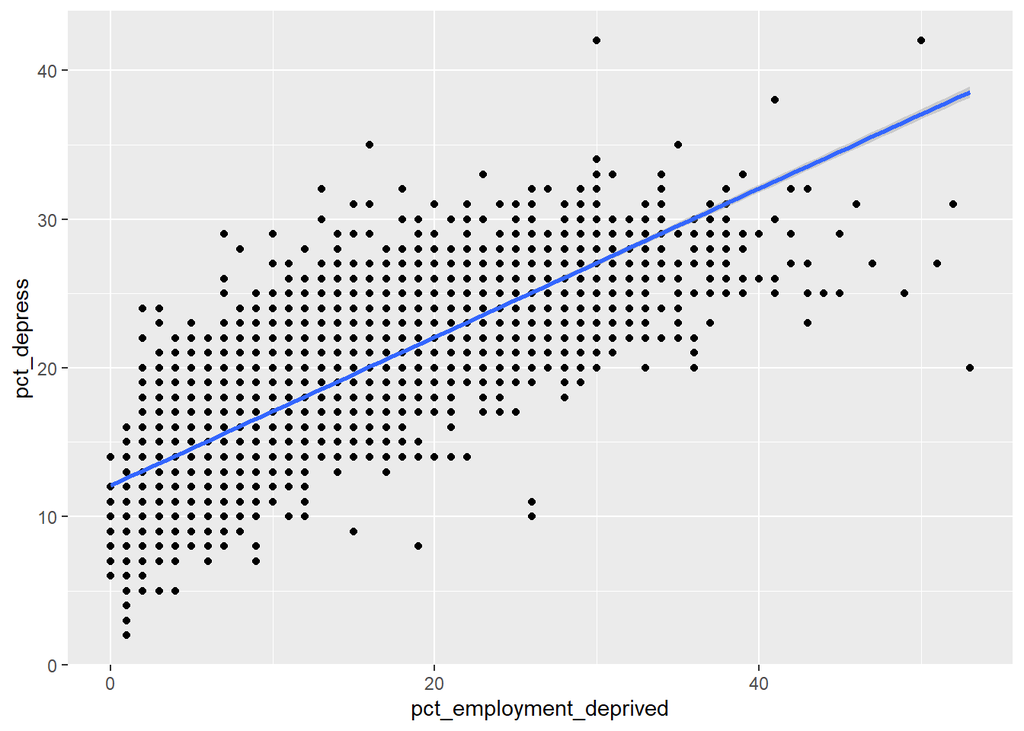

```r
ggplot(data=simd, aes(x=pct_employment_deprived, y=pct_depress)) +
   geom_point() +
   geom_smooth(method="lm", se=TRUE)
```

### Linear regression model using two variables

The relationship looks clear enough from the visualisation. Let’s use `lm` to model it. We will:

- Use `pct_depress` as our outcome/dependent variable
- Use `pct_employment_deprived` as our predictor variable

So, what we’re looking for here: **are zones with higher percentages of employment deprivation predictive of percentages of psych medication prescription?**

```r
model1 <- lm(pct_depress ~ pct_employment_deprived, data = simd)

summary(model1)
```

```
##
## Call:
## lm(formula = pct_depress ~ pct_employment_deprived, data = simd)
##
## Residuals:
##      Min       1Q   Median       3Q      Max
## -18.5504  -2.0711  -0.0763   1.9225  14.9358
##
## Coefficients:
##                          Estimate Std. Error t value Pr(>|t|)
## (Intercept)             12.082296   0.059443   203.3   <2e-16 ***
## pct_employment_deprived  0.499397   0.004362   114.5   <2e-16 ***
## ---
## Signif. codes:  0 '***' 0.001 '**' 0.01 '*' 0.05 '.' 0.1 ' ' 1
##
## Residual standard error: 2.966 on 6972 degrees of freedom
## Multiple R-squared:  0.6527, Adjusted R-squared:  0.6527
## F-statistic: 1.31e+04 on 1 and 6972 DF,  p-value: < 2.2e-16
```

> **Before interpreting this, let’s look back at the slides to remind us about what the regression coefficients mean (week 5 from slide 7)**

In the full model summary, our coefficient estimates are in the “Estimate” column, with the intercept first and then our slope value ($\beta_1$).

So the **slope coefficient / $\beta$ for `pct_employment_deprived` (our predictor) is 0.499397**.

The basic guide for interpreting coefficients is:

> **“For a one unit increase in our predictor variable, our outcome variable is expected to change by $\beta$.”** (Fogarty p.200)

We can get a handle on that in any regression also by thinking about how the numbers plug into the regression equation. Ignoring the intercept for the moment and just thinking about how y changes in proportion to $\beta$:

> **percent on prescription drugs = 0.499397 * percentage in employment deprivation**

Or:

> **y = 049 * $\beta$**

Or:

> **Y is about half of $\beta$**

Or:

> **For each one unit increase in $\beta$, y increases by 0.49.**

> **How would this translate into plain English, for our outcome (percentage prescribed psychiatric medication) and predictor (percentage of ‘employment deprivation’)?**

**Other things to notice in the model summary:**

- Coefficients are all statistically significant (at stronger than p < 0.001)
- R squared is high at 0.6527 (max. 1, if these two variables varied perfectly linearly with each other.) So `pct_employment_deprived` is “explaining” 65% of the variation in `pct_depress`.

### Multiple regression: adding extra covariates

Let’s add two new predictors to the model:

- `pct_overcrowded`: the percentage of people in overcrowded households in a datazone
- `urban`: a binary [0,1] variable where 1 = urban and 0 = rural.

If the **impact of percent of employment deprivation** on **percent on psychiatric medication** is the main hypothesis we’re looking at, here we’ll be able to examine that while **controlling for percent of overcrowding and whether the datazone is rural or urban**.

We just add those covariates to the model and find the summary as before:

```r
model2 <- lm(pct_depress ~ pct_employment_deprived + pct_overcrowded + urban, data = simd)

summary(model2)
```

```
##
## Call:
## lm(formula = pct_depress ~ pct_employment_deprived + pct_overcrowded +
##     urban, data = simd)
##
## Residuals:
##      Min       1Q   Median       3Q      Max
## -19.1216  -1.8840  -0.0604   1.8197  14.7903
##
## Coefficients:
##                          Estimate Std. Error t value Pr(>|t|)
## (Intercept)             12.289649   0.074528 164.900  < 2e-16 ***
## pct_employment_deprived  0.541167   0.005325 101.625  < 2e-16 ***
## pct_overcrowded         -0.080117   0.005735 -13.970  < 2e-16 ***
## urban                    0.306872   0.080853   3.795 0.000149 ***
## ---
## Signif. codes:  0 '***' 0.001 '**' 0.01 '*' 0.05 '.' 0.1 ' ' 1
##
## Residual standard error: 2.925 on 6970 degrees of freedom
## Multiple R-squared:  0.6622, Adjusted R-squared:  0.662
## F-statistic:  4554 on 3 and 6970 DF,  p-value: < 2.2e-16
```

Note firstly, R-squared is still high and adjust R-squared hasn’t dropped when adding more covariates. If adjusted R-squared had dropped, our extra covariates would be making the power of our model worse.

The `pct_employment_deprived` coefficient has increased a bit now other variables are being controlled for. The two new ones have the following values (rounding them):

- `pct_overcrowded`: -0.08.

Going back to the statement above: **“For a one unit increase in the predictor variable, our outcome variable is expected to change by $\beta$.”**

> **What’s the interpretation of the `pct_overcrowded` coefficient? Note that’s its sign is negative, so the slope is downwards.**

The `urban` coefficient is [0,1] so is functioning as a **dummy variable** - where when `urban = 1`, the value of `pct_depress` changes by the amount the coefficient indicates. **For this model, it’s 0.3.**

> **So: "If the datazone is urban, the percent of people taking psychiatric medication increases by 0.31%**

There are a couple of other useful ways to look at the results. We saw these last week, but let’s look again.

Firstly, we can ask R to tell us the **confidence intervals for the coefficients** (here setting them to 95% CIs):

```r
confint(model2, level = 0.95)
```

```
##                              2.5 %      97.5 %
## (Intercept)             12.1435521 12.43574610
## pct_employment_deprived  0.5307281  0.55160589
## pct_overcrowded         -0.0913589 -0.06887429
## urban                    0.1483751  0.46536905
```

Or we can **look at the same thing graphically.** Fogarty uses the ‘coefplot’ package to do this - it has some useful features. Install it using:

```r
install.packages('coefplot')
```

And then load the library. We can set two levels of confidence intervals if we want, but let’s just use one here (by setting outerCI to zero). Also, we exclude the intercept from the graphic. We’ll set the main CIs to 95% (i.e. 1.96 standard deviations each side of the coefficient):

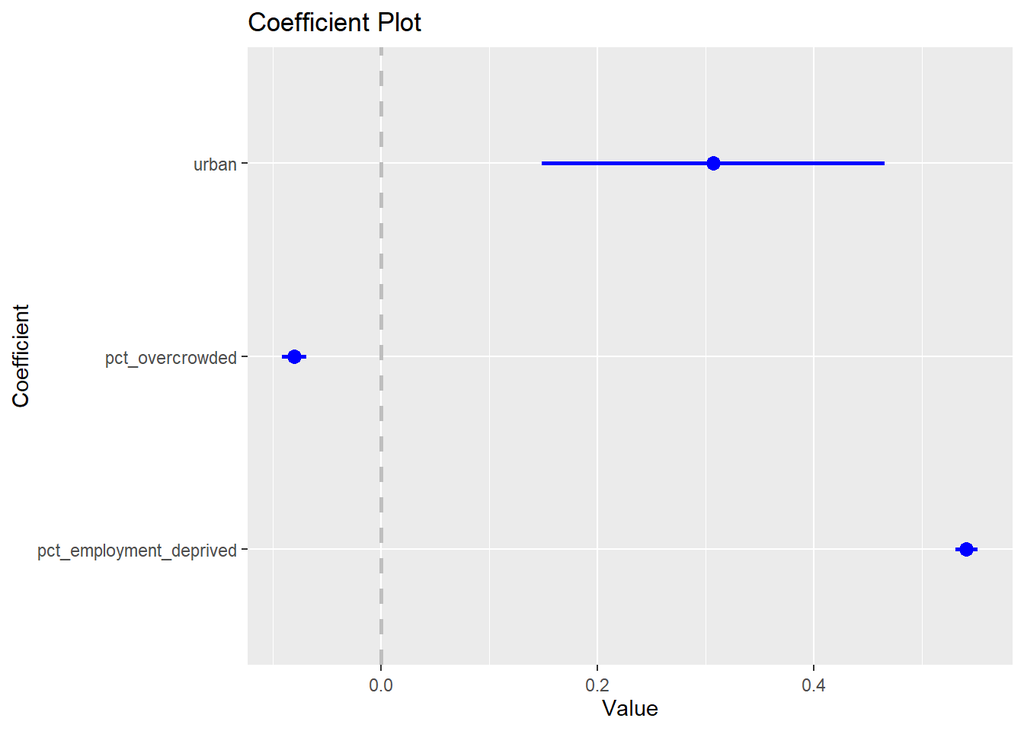

```r
library(coefplot)
coefplot(model2, innerCI = 1.96, outerCI = 0, intercept = FALSE)
```

Here, it’s easy to see that `urban` has quite large uncertainty around its coefficient compared to the other two.

> **Note: another way you can judge this is by looking at the t values in the model summary. The t value, recall, can be interpreted as “number of standard errors the coefficient is away from zero”. If a coefficient were only 2 or less standard errors away from zero, it would be close to being statistically insignificant, and you’d see its confidence intervals crossing zero when plotted.**

Fogarty has some useful suggestions for how we might describe these coefficient results in plain English:

- For the `pct_employment_deprived` coefficient: “For a one unit increase in the percentage of employment deprivation in a datazone, the percentage of psychiatric prescriptions is expected to increase by 0.541%, while controlling for other variables.” (Fogarty p.207)

We could add in the 95% confidence intervals to that sentence if we wanted e.g. “… expected to increase by 0.541% [95%s CIs 0.531-0.552] while controlling for other variables.”

- For the `pct_overcrowded` coefficient: “For a one unit increase in the percent of overcrowded housing in a datazone, the percentage of psychiatric prescriptions is expected to **decrease** by 0.08%.” (Ibid.)

Fogarty has another **very useful plain language interpretation here** that includes a note on **effect size**. Here, he’s exploring what we can see in the graphic and the confidence intervals: while we might be surprised to find this negative relationship, it’s only a tiny percentage, and much smaller than the 0.5% difference that employment deprivation makes. He puts it like this:

- “Datazones which have higher housing overcrowding tend to have lower percentages of psychiatric prescriptions. However, the effect size is very small. This suggests that overcrowding matters only slightly, particularly when compared with the effect of employment deprivation.” (p.208)
- For the binary/dummy variable `urban`: “Urban areas appear to have higher percentages of psychiatric prescriptions than rural areas; however, the difference is rather small at less than 0.5%.”

Note how, for that last one, you have to be aware of the different meanings of the coefficients: for `pct_employment_deprived`, 0.54 is a 0.54% percent change in psychiatric prescriptions for a **one unit** change in percent of employment deprivation. For `urban`, however, there’s just the one step-change between urban and rural, of 0.31%.

## Regression practice 2: using regression with a [0,1] binary outcome variable - linear probability model

It’s possible to use a binary variable (that takes values of **either** one **or** zero) as the outcome variable in regression. In later modules, you’ll learn about logistic regression, which is a good way of dealing with this kind of outcome. But it’s also possible to use a binary outcome variable in our normal lm regression - this is called a **linear probability model**.

Let’s have a look at one of these using the above **simd** data. We would most likely expect **overcrowding to be higher in more urban datazones**. But can we use regression to ask **“how much does the probability of being an urban datazone change for each 1% increase in overcrowding?”**

Let’s plot the data first.

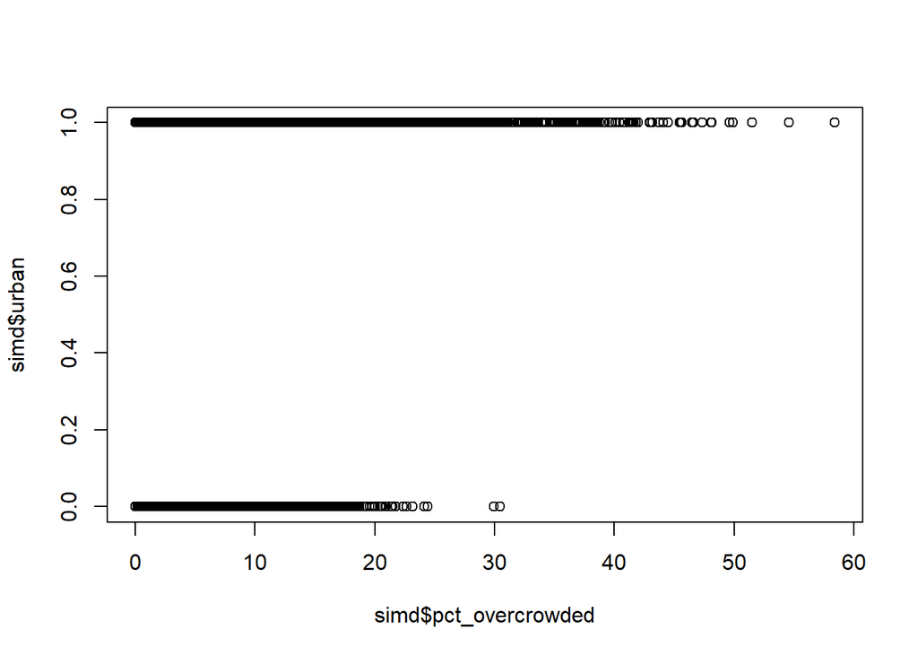

```r
plot(simd$urban ~ simd$pct_overcrowded)
```

Let’s model this using our standard regression formula - noting that we’re **using our binary `urban` variable as the dependent/outcome variable:

```r
model.p <- lm(urban ~ pct_overcrowded, data = simd)

summary(model.p)
```

```
##
## Call:
## lm(formula = urban ~ pct_overcrowded, data = simd)
##
## Residuals:
##     Min      1Q  Median      3Q     Max
## -1.0854 -0.5369  0.1906  0.3575  0.5264
##
## Coefficients:
##                  Estimate Std. Error t value Pr(>|t|)
## (Intercept)     0.4736401  0.0088990   53.22   <2e-16 ***
## pct_overcrowded 0.0200764  0.0006607   30.38   <2e-16 ***
## ---
## Signif. codes:  0 '***' 0.001 '**' 0.01 '*' 0.05 '.' 0.1 ' ' 1
##
## Residual standard error: 0.4334 on 6972 degrees of freedom
## Multiple R-squared:  0.1169, Adjusted R-squared:  0.1168
## F-statistic: 923.2 on 1 and 6972 DF,  p-value: < 2.2e-16
```

Now - because `urban` is a binary [0,1] variable, 1 can be interpreted as “probability that this datazone is urban = 1” (i.e. it’s certain), with 0 being “probability this datazone is urban = 0” (i.e. it’s definitely rural).

This means that **the change in the slope of a linear probablity model can be read as change in the probability of the outcome given a one unit change in the predictor variable or variables**.

So, in our case here, we have a `pct_overcrowded` coefficient of **0.02**. A one-unit change in `pct_overcrowded` is a one percent change. So this is saying: a one percent increase in overcrowding is associated with a 0.02 increase in the probability of a datazone being urban.

But we know probabilities are between 0 an 1: to make that slightly more readable, we can multiply it by a hundred, to read:

- “A one percent increase in overcrowding is associated with a 2% increase in the probability of a datazone being urban.”

We can also add that regression line to the plot, to see that graphically:

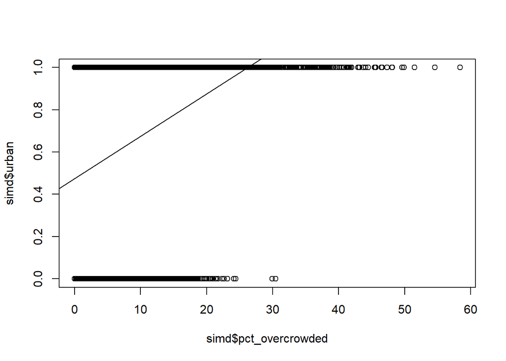

```r
plot(simd$urban ~ simd$pct_overcrowded)

abline(model.p)
```

So: **as long as you’re careful with how you interpret a binary outcome model like this**, it’s OK to use one.

Just a little bit of extra code to perhaps help with the intuition here. If we break the `pct_overcrowded` variable into deciles, we could find the probability of datazones being urban for each decile manually.

We can use the `cut_width` function from the `ggplot` package that’s part of the tidyverse. We just tell it the width of each bin (10 percentage points, in this case, to give us deciles):

```r
library(tidyverse)

simd$pct_overcrowded_decilebins <- cut_width(simd$pct_overcrowded,10)
table(simd$pct_overcrowded_decilebins)
```

```
##
##  [-5,5]  (5,15] (15,25] (25,35] (35,45] (45,55] (55,65]
##    1796    3431    1359     296      75      16       1
```

Table tells us how many observations are in each of our new bins. And we can use `tapply` to find the mean of `urban` for each - thus giving us the probability that each bin’s values are urban:

```r
tapply(simd$urban, simd$pct_overcrowded_decilebins, mean)
```

```
##    [-5,5]    (5,15]   (15,25]   (25,35]   (35,45]   (45,55]   (55,65]
## 0.5261693 0.6554940 0.9234731 0.9932432 1.0000000 1.0000000 1.0000000
```

We can see the same pattern the plot showed - increasing probability as overcrowding increases, going to 100% probablity after 35% overcrowding.

# Textual analysis

For text analysis, we’ll re-create the analysis we went through in the lecture - using R to investigate who wrote the contested Federalist papers. (This example is also in the Imai textbook, section 5.1).

Before we start, let’s **install the packages we’ll need**. Note we can **install multiple packages at once by putting their names into a vector inside the `install.packages` function**:

```r
install.packages(c('tm','SnowballC','wordcloud'))
```

```r
## load two required libraries
library(tm)
```

```r
library(SnowballC)
library(wordcloud)
```

Usually, you would load in a raw “corpus” of texts from a folder containing each document. That would look like this. The “fp” pattern is just telling `VCorpus` that each text file contains the text “fp” in its filename.

```r
## load the raw corpus
corpus.raw <- VCorpus(DirSource(directory = "federalist", pattern = "fp"))
```

However, let’s skip all the downloading/moving work and **jump straight to loading it in via URL**. Note again - we can use the `readRDS` function to load in **any R object**. I’ve previously saved `corpus.raw` produced in the code above using `saveRDS`. You can also do this, for example, for ggplots and other graphics, if you assign them to a variable name.

```r
corpus.raw <- readRDS(url('https://bit.ly/smi106corpus'))
```

We can take a quick look at how many documents there are in the corpus, and the top ten papers in the list:

```r
corpus.raw
```

```
## <<VCorpus>>
## Metadata:  corpus specific: 0, document level (indexed): 0
## Content:  documents: 85
```

```r
head(content(corpus.raw[[10]]))
```

```
## [1] "AMONG the numerous advantages promised by a well-constructed Union, none "
## [2] "        deserves to be more accurately developed than its tendency to break and "
## [3] "        control the violence of faction. The friend of popular governments never "
## [4] "        finds himself so much alarmed for their character and fate, as when he "
## [5] "        contemplates their propensity to this dangerous vice. He will not fail, "
## [6] "        therefore, to set a due value on any plan which, without violating the "
```

We then do all the various text processing stages to make the text consistent:

```r
## make lower case
corpus.prep <- tm_map(corpus.raw, content_transformer(tolower))
## remove white space
corpus.prep <- tm_map(corpus.prep, stripWhitespace)
## remove punctuation
corpus.prep <- tm_map(corpus.prep, removePunctuation)

## remove numbers
corpus.prep <- tm_map(corpus.prep, removeNumbers)
```

As part of processing, we also **remove stop words**. The `tm` package comes with a list of these. You can see what these are just with:

```r
stopwords("english")
```

We then use this to remove them from the corpus. The `stemDocument` function will reduce words to common stems, the part of the word containing just its meaning - for example stemming waited / waiting would just keep ‘wait’.

```r
## remove stop words
corpus <- tm_map(corpus.prep, removeWords, stopwords("english"))

## finally stem remaining words
corpus <- tm_map(corpus, stemDocument)
```

We can take a quick look at the result:

```r
## the output is truncated here to save space
content(corpus[[10]]) # Essay No. 10
```

## Making word clouds

We can use a **document term matrix** - just a table of terms and their counts in each of the documents in our corpus - to look at **word clouds for each document**. These will show us graphically what are the most common words - you’ll have likely seen these before.

We’ll just do a couple of those here.

```r
dtm <- DocumentTermMatrix(corpus)
dtm
```

```
## <<DocumentTermMatrix (documents: 85, terms: 4849)>>
## Non-/sparse entries: 44917/367248
## Sparsity           : 89%
## Maximal term length: 18
## Weighting          : term frequency (tf)
```

```r
#Just looking at a few
inspect(dtm[1:5, 100:110])
```

```
## <<DocumentTermMatrix (documents: 5, terms: 11)>>
## Non-/sparse entries: 13/42
## Sparsity           : 76%
## Maximal term length: 9
## Weighting          : term frequency (tf)
## Sample             :
##           Terms
## Docs       adversari advert advic advis advisori advoc aetolian affair affect
##   fp01.txt         1      0     0     0        0     1        0      0      2
##   fp02.txt         0      0     3     3        0     1        0      0      0
##   fp03.txt         0      0     0     1        0     0        0      0      4
##   fp04.txt         0      0     0     0        0     0        0      0      2
##   fp05.txt         0      1     0     0        0     1        0      1      3
##           Terms
## Docs       affin
##   fp01.txt     0
##   fp02.txt     0
##   fp03.txt     0
##   fp04.txt     0
##   fp05.txt     0
```

To make a word cloud, we first convert our document-term matrix to an actual R matrix, and we can then plot word clouds for particular Federalist papers.

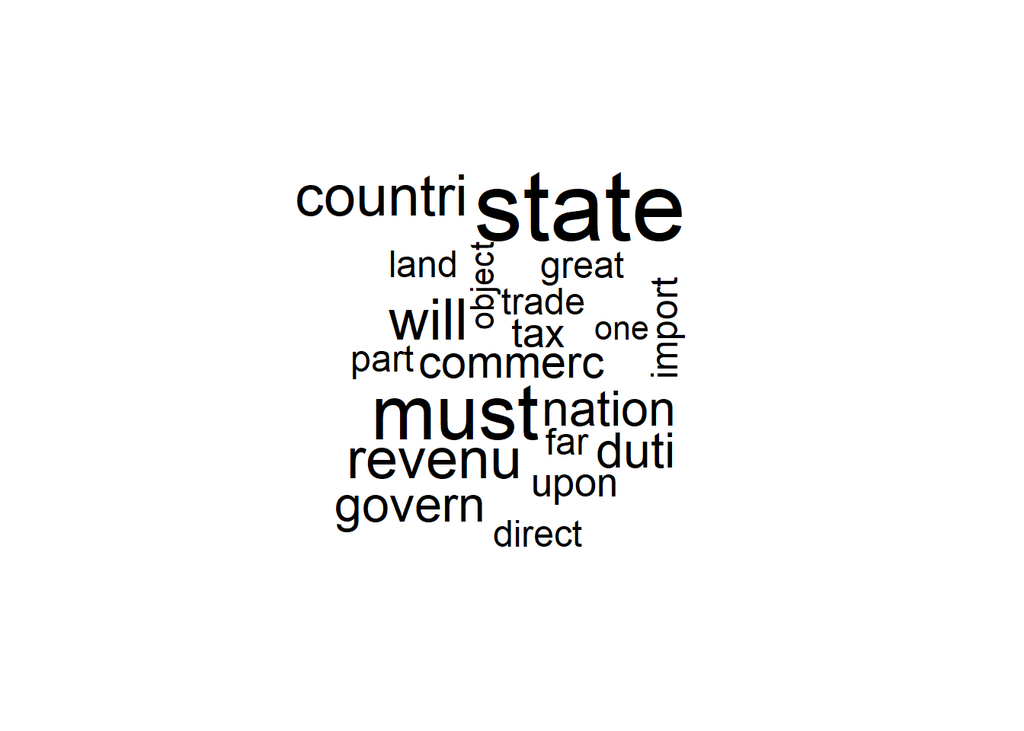

```r
dtm.mat <- as.matrix(dtm)


wordcloud(colnames(dtm.mat), dtm.mat[12, ], max.words = 20)  # essay No. 12
```

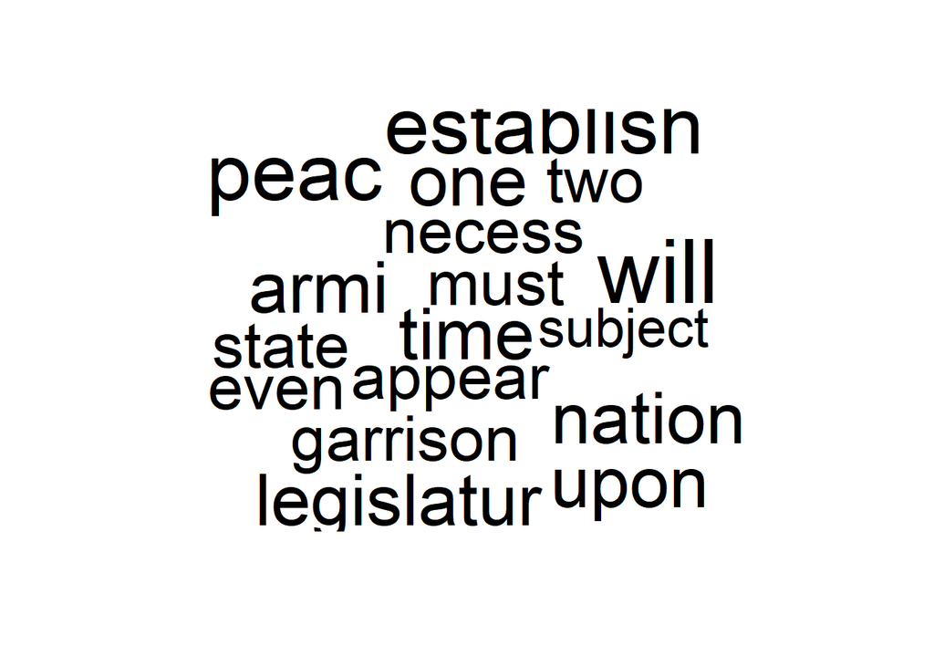

```r
wordcloud(colnames(dtm.mat), dtm.mat[24, ], max.words = 20)  # essay No. 24
```

## term frequency / inverse document frequency

Doing word clouds is an example of just doing “bag of words” analysis. We might want to attempt something a bit more sophisticated.

So to start with, we’ll find the **“term frequency / inverse document frequency”** (‘tf-idf’ for short) measure for terms in our corpus. The idea behind the measure is this - as Imai says, “A certain term’s high frequency *within* a document means little if that term often appears across **all** documents of the corpus. To address this issue, we should **downweight the terms that occur frequently across documents.**”

Again, the `tm` package has a function to calculate this - see the Imai textbook or the lecture for the maths (which is straightforward but we don’t need to go through here).

Let’s use that function, then see what the result says are the “most important” words for a couple of the Federalist papers:

```r
dtm.tfidf <- weightTfIdf(dtm) # tf-idf calculation

dtm.tfidf.mat <- as.matrix(dtm.tfidf)  # convert to matrix

## 10 most important words for Paper No. 12
head(sort(dtm.tfidf.mat[12, ], decreasing = TRUE), n = 10)
```

```
##     revenu contraband     patrol      excis      coast      trade        per
## 0.01905877 0.01886965 0.01886965 0.01876560 0.01592559 0.01473504 0.01420342
##        tax       cent     gallon
## 0.01295466 0.01257977 0.01257977
```

```r
## 10 most important words for Paper No. 24
head(sort(dtm.tfidf.mat[24, ], decreasing = TRUE), n = 10)
```

```
##   garrison   dockyard settlement      spain       armi   frontier    arsenal
## 0.02965511 0.01962294 0.01962294 0.01649040 0.01544256 0.01482756 0.01308196
##    western       post     nearer
## 0.01306664 0.01236780 0.01166730
```

We can see from the result that paper 12 has terms with an economy theme, whereas paper 24 is war-themed.

## Using that for k-means clustering

Let’s use the tf-idf ranking of words for a **k-means clustering** analysis. Here, we’ll identify clusters of similar essays by looking for word groups with similar tf-idf scores. With k-means, we choose the number of clusters.

Also, we’ll subset just to Hamilton’s essays.

This is definitely a lot to type out, I’d strongly recommending copy/pasting or using the supplied R script.

We can see from looking at the terms in each of the cluster of papers that there are common themes in each.

```r
k <- 4  # number of clusters
## subset The Federalist papers written by Hamilton
hamilton <- c(1, 6:9, 11:13, 15:17, 21:36, 59:61, 65:85)
dtm.tfidf.hamilton <- dtm.tfidf.mat[hamilton, ]

## run k-means
km.out <- kmeans(dtm.tfidf.hamilton, centers = k)
km.out$iter # check the convergence; number of iterations may vary
```

```
## [1] 2
```

```r
## label each centroid with the corresponding term
colnames(km.out$centers) <- colnames(dtm.tfidf.hamilton)

for (i in 1:k) { # loop for each cluster
    cat("CLUSTER", i, "\n")
    cat("Top 10 words:\n") # 10 most important terms at the centroid
    print(head(sort(km.out$centers[i, ], decreasing = TRUE), n = 10))
    cat("\n")
    cat("Federalist Papers classified: \n") # extract essays classified
    print(rownames(dtm.tfidf.hamilton)[km.out$cluster == i])
    cat("\n")
}
```

```
## CLUSTER 1
## Top 10 words:
##       trade    merchant    northern       navig  manufactur      revenu
## 0.013962253 0.012890018 0.010487956 0.010283154 0.009795735 0.009754859
##     commerc    southern      market confederaci
## 0.009501991 0.009303222 0.009179588 0.006984902
##
## Federalist Papers classified:
## [1] "fp11.txt" "fp12.txt" "fp13.txt" "fp35.txt"
##
## CLUSTER 2
## Top 10 words:
##       senat        upon      presid        armi     militia       claus
## 0.003837204 0.003826007 0.003379705 0.003313460 0.002788436 0.002570167
##       offic    militari         tax         war
## 0.002554169 0.002314628 0.002260486 0.002256539
##
## Federalist Papers classified:
##  [1] "fp01.txt" "fp06.txt" "fp07.txt" "fp08.txt" "fp09.txt" "fp15.txt"
##  [7] "fp16.txt" "fp17.txt" "fp21.txt" "fp22.txt" "fp23.txt" "fp24.txt"
## [13] "fp25.txt" "fp26.txt" "fp27.txt" "fp28.txt" "fp29.txt" "fp30.txt"
## [19] "fp31.txt" "fp32.txt" "fp33.txt" "fp34.txt" "fp36.txt" "fp59.txt"
## [25] "fp60.txt" "fp61.txt" "fp66.txt" "fp68.txt" "fp69.txt" "fp70.txt"
## [31] "fp71.txt" "fp72.txt" "fp73.txt" "fp74.txt" "fp75.txt" "fp76.txt"
## [37] "fp77.txt" "fp78.txt" "fp79.txt" "fp80.txt" "fp84.txt" "fp85.txt"
##
## CLUSTER 3
## Top 10 words:
##     vacanc     recess      claus      senat    session       fill    appoint
## 0.06953047 0.04437713 0.04082617 0.03408008 0.03313305 0.03101140 0.02211662
##     presid      expir    unfound
## 0.01852025 0.01738262 0.01684465
##
## Federalist Papers classified:
## [1] "fp67.txt"
##
## CLUSTER 4
## Top 10 words:
##       court        juri       appel   jurisdict       trial      tribun
## 0.045553185 0.031679369 0.014610450 0.014398568 0.013826016 0.012963605
##      suprem     impeach      cogniz    inferior
## 0.012739302 0.010427215 0.010077710 0.008663789
##
## Federalist Papers classified:
## [1] "fp65.txt" "fp81.txt" "fp82.txt" "fp83.txt"
```

## Authorship prediction

In this section, we’ll use text plus regression to try and identify who the mysterious “Publius” author of the Federalist papers is.

TO do this, we will:

- Compare the frequency of ten words in both the known Hamilton and Madison papers. The words are: “although”, “always”, “commonly”, “consequently”, “considerable”, “enough”, “there”, “upon”, “while”, “whilst”
- Once we can see what our model says about whether those words can successfully predict whether it’s Hamilton or Madison, we can use that to then predict the unknown papers.

We start off by finding term frequency per 1000 words for all words before subsetting to ones we want to look at:

```r
# document-term matrix converted to matrix for manipulation
dtm1 <- as.matrix(DocumentTermMatrix(corpus.prep))
tfm <- dtm1 / rowSums(dtm1) * 1000 # term frequency per 1000 words

# words of interest
words <- c("although", "always", "commonly", "consequently",
           "considerable", "enough", "there", "upon", "while", "whilst")

# select only these words
tfm <- tfm[, words]
```

A few preliminaries before we use regression to help with our prediction.

We will:

- Get a subset of Madison’s essays (we already got Hamilton’s above in the k-means code).
- Create a `tfm.ave` object to look at the frequency per 1000 words for Hamilton vs Madison.
- Make an `author.data` dataframe with the authors and term frequencies, that can be used in the regression

And a key thing we’re doing here:

- We label Hamilton as 1 and Madison as -1, so that when the regresion predicts where terms come from, **being above or below zero will be our predictive indicator.**

```r
## essays written by Madison: `hamilton' defined earlier
madison <- c(10, 14, 37:48, 58)

## average among Hamilton/Madison essays
tfm.ave <- rbind(colSums(tfm[hamilton, ]) / length(hamilton),
                 colSums(tfm[madison, ]) / length(madison))
tfm.ave
```

```
##        although    always  commonly consequently considerable    enough
## [1,] 0.01756975 0.7527744 0.2630876   0.02600857    0.5435127 0.3955031
## [2,] 0.27058809 0.2006710 0.0000000   0.44878468    0.1601669 0.0000000
##         there      upon     while      whilst
## [1,] 4.417750 4.3986828 0.3700484 0.007055719
## [2,] 1.113252 0.2000269 0.0000000 0.380113114
```

```r
author <- rep(NA, nrow(dtm1)) # a vector with missing values
author[hamilton] <- 1  # 1 if Hamilton
author[madison] <- -1  # -1 if Madison

## data frame for regression
author.data <- data.frame(author = author[c(hamilton, madison)],
                          tfm[c(hamilton, madison), ])
```

Take a look at the first few rows of `author.data` to see what’s going in to the regression.

- Each row is a paper
- It has a column for author (coded to 1 and -1)
- And columns for term frequency for our subset of words

```r
head(author.data)
```

|  | author | although | always | commonly | consequently | considerable | enough | there | upon | while. | whilst |
| --- | --- | --- | --- | --- | --- | --- | --- | --- | --- | --- | --- |
| fp01.txt | 1 | 0 | 0.8410429 | 0.8410429 | 0 | 0.0000000 | 0.8410429 | 1.682086 | 5.046257 | 0.000000 | 0 |
| fp06.txt | 1 | 0 | 0.0000000 | 0.0000000 | 0 | 1.3253810 | 0.6626905 | 5.301524 | 2.650762 | 0.000000 | 0 |
| fp07.txt | 1 | 0 | 0.0000000 | 0.5820722 | 0 | 0.0000000 | 0.0000000 | 5.238650 | 6.402794 | 0.000000 | 0 |
| fp08.txt | 1 | 0 | 1.9775873 | 0.6591958 | 0 | 0.6591958 | 1.3183916 | 1.318392 | 1.977587 | 0.000000 | 0 |
| fp09.txt | 1 | 0 | 0.0000000 | 0.0000000 | 0 | 0.6720430 | 0.6720430 | 2.016129 | 2.688172 | 0.672043 | 0 |
| fp11.txt | 1 | 0 | 0.0000000 | 0.0000000 | 0 | 1.0587612 | 0.0000000 | 4.235045 | 3.176284 | 0.000000 | 0 |

The `tfm.ave` object output gives us a look at term frequency for Hamilton (first row) vs Madison (second row). We can see e.g. that Hamilton uses ‘always’ a lot more, where Madison uses ‘consequently’ a lot more, and there are various other words that seem indicative of one or the other author.

We can use that fact in a normal linear regression - using **four** of our selected words as predictors, and the author as the outcome variable.

```r
hm.fit <- lm(author ~ upon + there + consequently + whilst,
             data = author.data)
hm.fit
```

```
##
## Call:
## lm(formula = author ~ upon + there + consequently + whilst, data = author.data)
##
## Coefficients:
##  (Intercept)          upon         there  consequently        whilst
##     -0.26288       0.16678       0.09494      -0.44012      -0.65875
```

Predictors closer to one are saying "these are more likely to be written by Hamilton; those closer to -1 are more likely to be written by Madison.

We can then use the `fitted` function to see exactly what value for the outcome variable for each observation (each of Hamilton’s vs Madison’s papers) the regression predicts. Looking at the raw values, we can see which are closer to 1 or -1:

```r
hm.fitted <- fitted(hm.fit) # fitted values
```

```r
hm.fitted
```

And we can actually check what proportion of each is being correctly classified:

```r
# proportion of correctly classified essays by Hamilton
mean(hm.fitted[author.data$author == 1] > 0)
```

```
## [1] 1
```

```r
# proportion of correctly classified essays by Madison
mean(hm.fitted[author.data$author == -1] < 0)
```

```
## [1] 1
```

One way to do **cross-validation** (to check using out-of-sample data to see how well or model does) is what’s called “leave-one-out cross validation”, where we **take one row out** of the data, run our model, and then see how the model does at predicting the one we left out.

A way to do this in R is to use a **for loop** to run through the whole dataset, taking one out, then checking prediction against the one that’s been left out.

Again, it’s a big clump of code so I’d copy/paste and run:

```r
n <- nrow(author.data)
hm.classify <- rep(NA, n) # a container vector with missing values

for (i in 1:n) {
    ## fit the model to the data after removing the ith observation
    sub.fit <- lm(author ~ upon + there + consequently + whilst,
                  data = author.data[-i, ]) # exclude ith row
    ## predict the authorship for the ith observation
    hm.classify[i] <- predict(sub.fit, newdata = author.data[i, ])
}

## proportion of correctly classified essays by Hamilton
mean(hm.classify[author.data$author == 1] > 0)
```

```
## [1] 1
```

```r
## proportion of correctly classified essays by Madison
mean(hm.classify[author.data$author == -1] < 0)
```

```
## [1] 1
```

We see it’s managing to predict all of the left-out rows of the data successfully.

## Predicting the unknown papers’ author

Our last job is to use this model to make predictions on who wrote the mysterious ‘Publius’ papers.

Once we have our model, and the fitted values the model predicts, R makes it easy to use that to make predictions from new data.

First, we get a subset of the disputed papers. then use the `predict` function to do the prediction of the author value for us.

```r
disputed <- c(49, 50:57, 62, 63) # 11 essays with disputed authorship
tf.disputed <- as.data.frame(tfm[disputed, ])

#Term frequency in the disputed papers
tf.disputed
```

|  | although | always | commonly | consequently | considerable | enough | there | upon | while | whilst |
| --- | --- | --- | --- | --- | --- | --- | --- | --- | --- | --- |
| fp49.txt | 0.0000000 | 0.8090615 | 0.0000000 | 0.8090615 | 0.0000000 | 0 | 1.6181230 | 0.000000 | 0 | 0.8090615 |
| fp50.txt | 1.1709602 | 0.0000000 | 0.0000000 | 0.0000000 | 0.0000000 | 0 | 0.0000000 | 1.170960 | 0 | 0.0000000 |
| fp51.txt | 0.0000000 | 0.0000000 | 0.0000000 | 1.3966480 | 0.0000000 | 0 | 2.7932961 | 0.000000 | 0 | 1.3966480 |
| fp52.txt | 0.0000000 | 0.7137759 | 0.0000000 | 0.0000000 | 0.0000000 | 0 | 0.0000000 | 0.000000 | 0 | 0.0000000 |
| fp53.txt | 0.6035003 | 0.0000000 | 0.0000000 | 0.0000000 | 0.0000000 | 0 | 1.2070006 | 0.000000 | 0 | 0.6035003 |
| fp54.txt | 0.6702413 | 0.0000000 | 0.0000000 | 1.3404826 | 0.6702413 | 0 | 0.6702413 | 1.340483 | 0 | 0.0000000 |
| fp55.txt | 0.0000000 | 0.6459948 | 0.0000000 | 0.0000000 | 0.6459948 | 0 | 3.2299742 | 0.000000 | 0 | 0.0000000 |
| fp56.txt | 0.0000000 | 0.0000000 | 0.0000000 | 0.0000000 | 1.6488046 | 0 | 2.4732069 | 0.000000 | 0 | 0.8244023 |
| fp57.txt | 0.0000000 | 0.6013229 | 0.0000000 | 0.0000000 | 0.0000000 | 0 | 2.4052916 | 0.000000 | 0 | 1.8039687 |
| fp62.txt | 0.0000000 | 0.5633803 | 0.0000000 | 1.6901408 | 0.5633803 | 0 | 0.0000000 | 0.000000 | 0 | 0.0000000 |

[output cut: 1 more lines]

```r
## prediction of disputed authorship
pred <- predict(hm.fit, newdata = tf.disputed)
pred # predicted values
```

```
##    fp49.txt    fp50.txt    fp51.txt    fp52.txt    fp53.txt    fp54.txt
## -0.99831799 -0.06759254 -1.53243206 -0.26288400 -0.54584900 -0.56566555
##    fp55.txt    fp56.txt    fp57.txt    fp62.txt    fp63.txt
##  0.04376632 -0.57115610 -1.22289415 -1.00675456 -0.21939646
```

You can clearly see the prediction is showing the outcome variable (the author value, -1 for Madison, 1 for Hamilton) is below zero for all but one of the disputed papers (one has a positive value that’s quite close to zero).

Lastly, we can use all this information to **make a plot** showing the fitted values for Hamilton (red), Madison (blue) and the disputed papers (black triangles).

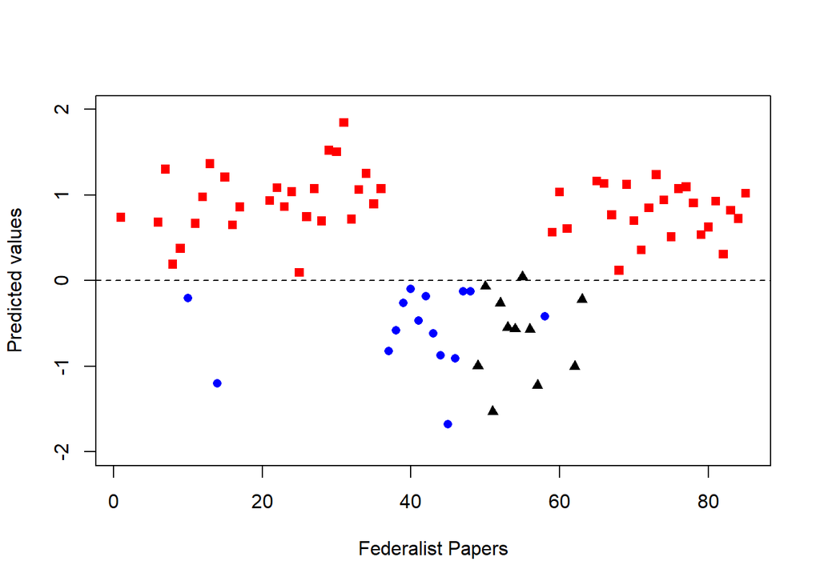

```r
# fitted values for essays authored by Hamilton; red squares
plot(hamilton, hm.fitted[author.data$author == 1], pch = 15,
     xlim = c(1, 85), ylim  = c(-2, 2), col = "red",
     xlab = "Federalist Papers", ylab = "Predicted values")
abline(h = 0, lty = "dashed")

# essays authored by Madison; blue circles
points(madison, hm.fitted[author.data$author == -1],
       pch = 16, col = "blue")

# disputed authorship; black triangles
points(disputed, pred, pch = 17)
```